# PCFL: Week 5 wrap-up

### Last week’s games

| away_team | awaypoints | home_team | homepoints |
| --- | --- | --- | --- |
| Pigskin on the Gridiron | 96.62 | KC Gophers | 120.26 |
| Athens Team Sasquatch | 118.95 | First Timers The FTs | 117.82 |
| Georgia Peanuts | 108.54 | Captain Clairvoyant | 121.40 |
| Middle Earth Hangry Hobbits | 142.36 | The G.O.A.T. | 125.90 |
| Jumpin’ Jaheims | 103.72 | Southern Sharks | 97.83 |

Congrats to Evan for getting his first win! He didn’t have a great scoring week, but it was a big enough boat to down Sarah’s Sharks. Team Sasquatch (Robbie) also managed to stomp on the First Timers’ hot streak. And the Hangry Hobbits were this week’s point leaders. Much rejoicing reported from the Shire.

#### Best performing players

Here’s last week’s **10 best performing players.** The bench variable shows whether they got left on the bench or not.

| name | points | fullname | bench |
| --- | --- | --- | --- |
| Ryan Tannehill | 30.00 | Middle Earth Hangry Hobbits | 1 |
| Patrick Mahomes | 29.70 | First Timers The FTs | 0 |
| Justin Herbert | 27.36 | Jumpin’ Jaheims | 1 |
| Kyler Murray | 26.30 | The G.O.A.T. | 0 |
| Brandin Cooks | 26.10 | The G.O.A.T. | 1 |
| Mike Davis | 25.40 | Georgia Peanuts | 0 |
| Ravens D/ST | 25.00 | Middle Earth Hangry Hobbits | 0 |
| Deshaun Watson | 24.86 | Middle Earth Hangry Hobbits | 0 |
| Adam Thielen | 24.80 | First Timers The FTs | 0 |
| Russell Wilson | 24.48 | Southern Sharks | 1 |

Quarterback heavy numbers here–the top four players were all under center last week, and QBs were 6 of the top 10. The Ravens’ defense powered the Hobbits’ win this week with 25 (!) points. Mike Davis’ days as a starter for me may be numbered, but he’s done well stepping in when injury gave an opportunity.

#### Best addition and worst starters

There were 8 players added last week. Which was the **best new addition**?

| add_date | name | points | fullname |
| --- | --- | --- | --- |
| 2020-10-09 | Justin Herbert | 27.36 | Jumpin’ Jaheims |
| 2020-10-10 | Jamison Crowder | 22.00 | Athens Team Sasquatch |
| 2020-10-08 | Teddy Bridgewater | 20.82 | Athens Team Sasquatch |
| 2020-10-08 | Chase Edmonds | 19.25 | Athens Team Sasquatch |
| 2020-10-11 | Cardinals D/ST | 8.00 | Southern Sharks |
| 2020-10-08 | Stephen Gostkowski | 6.00 | KC Gophers |
| 2020-10-08 | Bears D/ST | 5.00 | Georgia Peanuts |
| 2020-10-08 | Eric Ebron | 4.80 | Athens Team Sasquatch |

Team Sasquatch had three great adds this week, but Justin Herbert also did great for Evan.

Who should have been **left on the bench** this week–the lowest points scored by starters?

| name | points | fullname |
| --- | --- | --- |
| Chiefs D/ST | -5 | Captain Clairvoyant |
| 49ers D/ST | -4 | First Timers The FTs |
| Davante Adams | 0 | Georgia Peanuts |
| Robert Tonyan | 0 | Georgia Peanuts |
| Kenny Golladay | 0 | Southern Sharks |
| Aaron Rodgers | 0 | Captain Clairvoyant |
| Mason Crosby | 0 | Captain Clairvoyant |
| Julio Jones | 0 | Pigskin on the Gridiron |
| T.J. Hockenson | 0 | Pigskin on the Gridiron |

Start a defense at your peril. The Chiefs were having a good run, but came back to earth this week (even if Brian still pulled out the W). The 49ers also had an off week.

Who won the **best scoring bench** award last week?

| fullname | points |
| --- | --- |
| Middle Earth Hangry Hobbits | 95.25 |
| Southern Sharks | 91.13 |
| Jumpin’ Jaheims | 82.36 |
| Athens Team Sasquatch | 78.42 |
| The G.O.A.T. | 72.26 |
| Captain Clairvoyant | 67.15 |
| Georgia Peanuts | 63.64 |
| Pigskin on the Gridiron | 61.20 |
| First Timers The FTs | 51.82 |
| KC Gophers | 37.87 |

Hangry Hobbits had points to spare! 95 points for them. It appears that Sarah could have used some points off the bench.

### League standings and season stats

Here’s a look at our current standings

| fullname | division | W | L | points_scored | points_allowed | points_rank | playoff_rank |
| --- | --- | --- | --- | --- | --- | --- | --- |
| Captain Clairvoyant | Grits | 4 | 1 | 644.72 | 555.44 | 2 | 1 |
| Athens Team Sasquatch | Grits | 4 | 1 | 586.61 | 577.64 | 4 | 2 |
| First Timers The FTs | Hot Dish | 3 | 2 | 672.28 | 578.97 | 1 | 3 |
| The G.O.A.T. | Grits | 3 | 2 | 606.49 | 592.31 | 3 | 4 |
| KC Gophers | Hot Dish | 3 | 2 | 530.19 | 541.20 | 9 | 5 |
| Georgia Peanuts | Hot Dish | 2 | 3 | 580.36 | 594.37 | 5 | 6 |
| Middle Earth Hangry Hobbits | Hot Dish | 2 | 3 | 579.62 | 580.03 | 6 | 7 |
| Southern Sharks | Hot Dish | 2 | 3 | 567.47 | 567.29 | 7 | 8 |
| Jumpin’ Jaheims | Grits | 1 | 4 | 536.16 | 623.81 | 8 | 9 |
| Pigskin on the Gridiron | Grits | 1 | 4 | 504.40 | 597.24 | 10 | 10 |

Here’s a list of the **top five scoring performances** so far this season.

| fullname | week | points_scored | result |
| --- | --- | --- | --- |
| First Timers The FTs | 2 | 171.28 | W |
| Captain Clairvoyant | 3 | 150.32 | W |
| Middle Earth Hangry Hobbits | 5 | 142.36 | W |
| First Timers The FTs | 4 | 141.14 | W |
| The G.O.A.T. | 1 | 139.20 | W |

Scott’s hot week puts the Hobbits in as our new #3.

Lastly, here’s a look at the **points trendline** for each team.

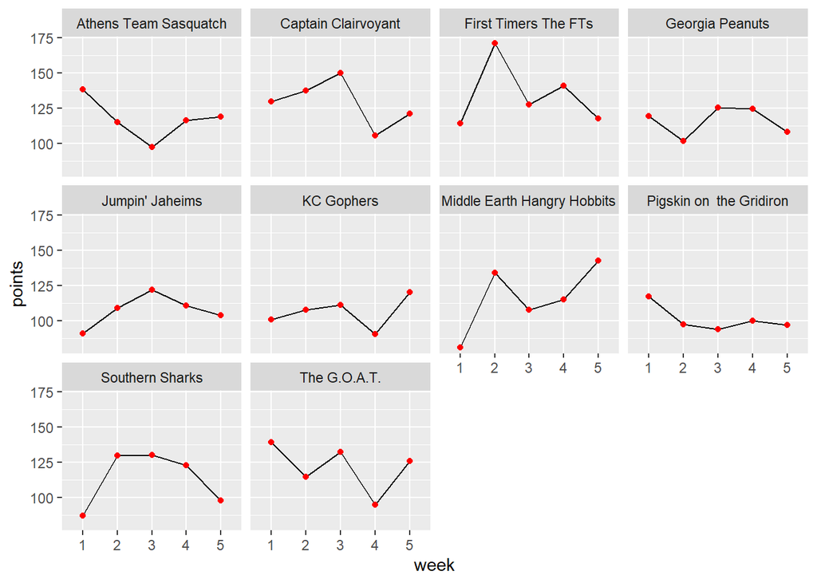

## Next week’s games

Here’s a quick summary of next week’s matchups:

| week | away_team | away_points | home_team | home_points | range |
| --- | --- | --- | --- | --- | --- |
| 6 | Middle Earth Hangry Hobbits | 579.62 | Georgia Peanuts | 580.36 | 0.74 |
| 6 | The G.O.A.T. | 606.49 | Jumpin’ Jaheims | 536.16 | 70.33 |
| 6 | First Timers The FTs | 672.28 | Southern Sharks | 567.47 | 104.81 |
| 6 | KC Gophers | 530.19 | Captain Clairvoyant | 644.72 | 114.53 |
| 6 | Athens Team Sasquatch | 586.61 | Pigskin on the Gridiron | 504.40 | 82.21 |

It’s a Stertz sister matchup between the First Timers and Sharks this week, so sparks will surely fly. KC Gophers will have to dig deep to see if their luck holds out against Captain Clairvoyant. The closest matchup of the week is me against Scott–we’ll see how hungry those hobbits really are. Good luck all!